# What qualities make Novak Djokovic so dominant at tennis? With a bonus discussion of Data Science, Tennis, and Basketball.

In the year 2021, Novak Djokovic has dominated the ATP tour, winning the first three grand slams to equal his career rivals, Rafael Nadal and Roger Federer at 20 grand slams each. In this document, we will examine attributes in Novak Djokovic's game by utilization of "The Data Science Pipeline". This pipeline is comprised of 5 stages: 1. Data Collection, 2. Data Management, 3. Exploratory Data Analysis, 4. Machine Learning, and 5. Communication of Insights Attained.

# Section 1: Data Collection

```python
import datetime
import pandas as pd
import requests as req
from bs4 import BeautifulSoup
import datetime
import numpy as np
import matplotlib.pyplot as plt
import seaborn as sns
from sklearn import linear_model
from sklearn.metrics import r2_score

pd.set_option('display.max_columns', None)

data1 = pd.read_csv("tennis.tsv", sep='\t')
data2 = pd.read_csv("tennis2.tsv", sep='\t')
data3 = pd.read_csv("tennis3.tsv", sep='\t')
data4 = pd.read_csv("tennis4.tsv", sep='\t')

df = data1.merge(data2)
df = df.merge(data3)
df
```

|  | Rk | Player | M | M W-L | M W% | SPW | SPW-InP | Aces | Ace% | DFs | DF% | DF/2s | 1stIn | 1st% | 2nd% | 2%-InP | Hld% | Pts/SG | PtsL/SG | RPW | RPW-InP | vAce% | vDF% | v1st% | v2nd% | Brk% | Pts/RG | PtsW/RG | MdOppRk | … |
| --- | --- | --- | --- | --- | --- | --- | --- | --- | --- | --- | --- | --- | --- | --- | --- | --- | --- | --- | --- | --- | --- | --- | --- | --- | --- | --- | --- | --- | --- | --- |
| 0 | 1 | Novak Djokovic [SRB] | 65 | 57-8 | 87.70% | 67.40% | 67.20% | 425 | 7.70% | 192 | 3.50% | 9.80% | 64.30% | 74.90% | 53.80% | 59.60% | 85.90% | 6.2 | 2.0 | 43.40% | 44.40% | 6.60% | 3.60% | 36.00% | 55.60% | 34.20% | 6.8 | 3.0 | 31.0 | … |
| 1 | 2 | Daniil Medvedev [RUS] | 63 | 49-14 | 77.80% | 68.80% | 67.40% | 580 | 12.20% | 184 | 3.90% | 10.00% | 61.40% | 79.00% | 52.50% | 58.40% | 87.10% | 5.9 | 1.8 | 40.90% | 41.00% | 5.00% | 3.20% | 32.20% | 55.60% | 28.90% | 6.6 | 2.7 | 37.0 | … |
| 2 | 3 | Rafael Nadal [ESP] | 45 | 37-8 | 82.20% | 66.80% | 67.20% | 166 | 4.80% | 99 | 2.80% | 7.90% | 64.10% | 72.90% | 56.10% | 60.90% | 85.10% | 6.1 | 2.0 | 43.50% | 44.50% | 6.60% | 3.50% | 35.60% | 56.70% | 36.30% | 6.4 | 2.8 | 18.0 | … |
| 3 | 4 | Stefanos Tsitsipas [GRE] | 76 | 56-20 | 73.70% | 68.60% | 67.70% | 491 | 8.00% | 158 | 2.60% | 7.30% | 64.40% | 74.90% | 57.10% | 61.50% | 87.20% | 6.1 | 1.9 | 38.30% | 38.40% | 5.50% | 3.40% | 30.80% | 51.40% | 24.80% | 6.4 | 2.5 | 32.0 | … |
| 4 | 5 | Alexander Zverev [GER] | 66 | 49-17 | 74.20% | 67.10% | 67.40% | 683 | 11.90% | 352 | 6.10% | 18.20% | 66.30% | 76.80% | 48.10% | 58.80% | 83.50% | 6.1 | 2.0 | 40.30% | 39.90% | 4.60% | 3.80% | 33.60% | 51.90% | 28.80% | 6.7 | 2.7 | 42.0 | … |
| 5 | 6 | Dominic Thiem [AUT] | 39 | 25-14 | 64.10% | 65.20% | 64.80% | 223 | 6.40% | 95 | 2.70% | 7.50% | 63.60% | 72.90% | 51.90% | 56.10% | 81.90% | 6.4 | 2.2 | 38.10% | 38.70% | 6.50% | 3.20% | 30.80% | 50.90% | 25.70% | 6.4 | 2.4 | 32.0 | … |
| 6 | 7 | Andrey Rublev [RUS] | 80 | 62-18 | 77.50% | 68.00% | 66.10% | 569 | 9.50% | 121 | 2.00% | 5.00% | 59.40% | 77.60% | 53.90% | 56.70% | 86.60% | 6.0 | 1.9 | 40.00% | 41.30% | 9.10% | 4.30% | 31.30% | 54.00% | 27.70% | 6.5 | 2.6 | 42.5 | … |
| 7 | 8 | Matteo Berrettini [ITA] | 52 | 40-12 | 76.90% | 71.00% | 68.20% | 555 | 13.20% | 84 | 2.00% | 5.50% | 63.60% | 80.40% | 54.80% | 57.90% | 90.40% | 5.9 | 1.7 | 37.30% | 37.10% | 5.30% | 3.50% | 30.80% | 48.10% | 21.70% | 6.5 | 2.4 | 42.0 | … |
| 8 | 9 | Roger Federer [SUI] | 13 | 9-4 | 69.20% | 67.80% | 65.50% | 109 | 8.50% | 11 | 0.90% | 2.50% | 65.80% | 73.50% | 56.80% | 58.30% | 87.10% | 6.1 | 2.0 | 35.40% | 36.20% | 7.90% | 3.30% | 28.30% | 47.80% | 17.80% | 6.4 | 2.3 | 41.5 | … |
| 9 | 10 | Denis Shapovalov [CAN] | 57 | 35-22 | 61.40% | 66.50% | 68.00% | 516 | 10.40% | 352 | 7.10% | 17.30% | 59.00% | 76.60% | 51.90% | 62.70% | 85.70% | 6.2 | 2.1 | 37.50% | 36.90% | 4.20% | 3.50% | 30.60% | 49.50% | 23.60% | 6.4 | 2.4 | 49.0 | … |
| 10 | 11 | Pablo Carreno Busta [ESP] | 52 | 37-15 | 71.20% | 65.00% | 64.30% | 196 | 4.80% | 69 | 1.70% | 5.50% | 69.00% | 69.90% | 54.00% | 57.10% | 81.20% | 6.2 | 2.2 | 39.40% | 40.80% | 8.20% | 3.40% | 31.10% | 52.80% | 28.00% | 6.4 | 2.5 | 45.0 | … |
| 11 | 12 | Hubert Hurkacz [POL] | 47 | 27-20 | 57.40% | 65.30% | 63.50% | 389 | 9.90% | 117 | 3.00% | 8.00% | 62.60% | 74.00% | 50.70% | 55.10% | 82.00% | 6.4 | 2.2 | 36.00% | 35.70% | 5.60% | 3.70% | 28.50% | 48.50% | 20.50% | 6.5 | 2.3 | 56.0 | … |
| 12 | 13 | Diego Sebastian Schwartzman [ARG] | 56 | 34-22 | 60.70% | 59.60% | 61.20% | 68 | 1.50% | 158 | 3.50% | 9.80% | 63.90% | 64.90% | 50.20% | 55.60% | 71.80% | 6.4 | 2.6 | 43.60% | 43.90% | 5.70% | 4.00% | 36.50% | 55.10% | 36.40% | 6.5 | 2.8 | 46.5 | … |
| 13 | 14 | Casper Ruud [NOR] | 55 | 38-17 | 69.10% | 65.80% | 65.60% | 234 | 5.80% | 109 | 2.70% | 7.50% | 64.40% | 71.30% | 56.00% | 60.60% | 83.50% | 6.1 | 2.1 | 39.20% | 39.20% | 5.90% | 3.70% | 31.00% | 51.90% | 26.20% | 6.5 | 2.6 | 46.0 | … |
| 14 | 15 | Felix Auger Aliassime [CAN] | 58 | 34-24 | 58.60% | 66.40% | 66.10% | 487 | 11.00% | 233 | 5.30% | 14.30% | 63.10% | 74.70% | 52.20% | 60.90% | 82.00% | 6.1 | 2.0 | 36.90% | 36.40% | 5.00% | 3.60% | 30.30% | 48.40% | 22.40% | 6.3 | 2.3 | 55.5 | … |
| 15 | 16 | Roberto Bautista Agut [ESP] | 55 | 34-21 | 61.80% | 63.50% | 63.50% | 174 | 3.90% | 101 | 2.30% | 6.80% | 66.50% | 68.10% | 54.40% | 58.30% | 78.10% | 6.2 | 2.3 | 40.20% | 42.50% | 10.40% | 3.70% | 30.10% | 55.80% | 28.20% | 6.6 | 2.6 | 42.0 | … |
| 16 | 17 | Alex De Minaur [AUS] | 48 | 27-21 | 56.30% | 62.90% | 63.50% | 145 | 3.80% | 117 | 3.10% | 7.80% | 60.10% | 69.80% | 52.50% | 57.00% | 78.10% | 6.5 | 2.4 | 39.90% | 40.50% | 6.40% | 3.30% | 32.80% | 51.50% | 26.60% | 6.7 | 2.7 | 52.0 | … |
| 17 | 18 | Gael Monfils [FRA] | 16 | 3-13 | 18.80% | 58.50% | 59.10% | 118 | 7.30% | 99 | 6.10% | 16.30% | 62.50% | 68.40% | 42.00% | 50.20% | 72.20% | 6.7 | 2.8 | 36.80% | 35.50% | 3.00% | 3.70% | 29.70% | 48.50% | 19.40% | 6.5 | 2.4 | 91.5 | … |
| 18 | 19 | Christian Garin [CHI] | 41 | 24-17 | 58.50% | 61.50% | 61.80% | 222 | 5.80% | 151 | 3.90% | 10.20% | 61.40% | 69.20% | 49.40% | 55.00% | 76.90% | 6.5 | 2.5 | 39.60% | 39.60% | 5.50% | 3.70% | 33.20% | 49.50% | 26.80% | 6.7 | 2.7 | 58.5 | … |
| 19 | 20 | David Goffin [BEL] | 36 | 18-18 | 50.00% | 60.50% | 60.90% | 184 | 6.30% | 136 | 4.60% | 11.30% | 59.00% | 70.50% | 46.10% | 52.00% | 74.70% | 6.7 | 2.6 | 39.00% | 39.70% | 6.60% | 3.30% | 30.80% | 52.60% | 26.50% | 6.3 | 2.5 | 61.0 | … |
| 20 | 21 | Grigor Dimitrov [BUL] | 37 | 22-15 | 59.50% | 63.90% | 65.10% | 162 | 5.40% | 143 | 4.80% | 12.90% | 63.00% | 71.70% | 50.60% | 58.10% | 81.20% | 6.5 | 2.3 | 40.00% | 40.30% | 5.80% | 3.40% | 33.20% | 50.90% | 27.60% | 6.5 | 2.6 | 56.0 | … |
| 21 | 22 | Milos Raonic [CAN] | 31 | 21-10 | 67.70% | 72.30% | 69.40% | 472 | 21.80% | 116 | 5.40% | 14.30% | 62.50% | 82.00% | 56.30% | 65.70% | 91.90% | 5.8 | 1.6 | 36.60% | 36.90% | 6.70% | 3.50% | 29.60% | 47.80% | 19.90% | 6.5 | 2.4 | 45.0 | … |
| 22 | 23 | Jannik Sinner [ITA] | 60 | 40-20 | 66.70% | 62.60% | 62.50% | 237 | 4.80% | 133 | 2.70% | 7.00% | 61.70% | 68.70% | 52.90% | 56.90% | 78.50% | 6.6 | 2.5 | 40.10% | 40.10% | 5.40% | 3.60% | 32.30% | 51.90% | 27.80% | 6.5 | 2.6 | 43.5 | … |
| 23 | 24 | Aslan Karatsev [RUS] | 49 | 34-15 | 69.40% | 65.50% | 66.40% | 252 | 6.90% | 175 | 4.80% | 11.70% | 58.90% | 74.00% | 53.40% | 60.40% | 82.80% | 6.1 | 2.1 | 39.40% | 40.20% | 6.80% | 3.20% | 32.10% | 51.60% | 27.60% | 6.4 | 2.5 | 58.5 | … |
| 24 | 25 | Karen Khachanov [RUS] | 53 | 30-23 | 56.60% | 64.30% | 63.30% | 354 | 7.30% | 131 | 2.70% | 7.50% | 63.80% | 71.30% | 51.90% | 56.10% | 81.40% | 6.4 | 2.3 | 37.60% | 38.30% | 6.90% | 3.10% | 28.60% | 52.00% | 22.30% | 6.5 | 2.4 | 55.0 | … |
| 25 | 26 | Lorenzo Sonego [ITA] | 55 | 32-23 | 58.20% | 65.10% | 64.10% | 294 | 6.70% | 98 | 2.20% | 6.50% | 65.80% | 72.30% | 51.20% | 54.80% | 81.80% | 6.3 | 2.2 | 37.20% | 36.50% | 4.10% | 3.50% | 30.60% | 48.40% | 22.80% | 6.5 | 2.4 | 49.0 | … |
| 26 | 27 | Daniel Evans [GBR] | 42 | 21-21 | 50.00% | 62.70% | 62.80% | 171 | 4.80% | 107 | 3.00% | 7.70% | 61.30% | 69.70% | 51.60% | 55.90% | 79.40% | 6.7 | 2.5 | 37.80% | 38.50% | 7.00% | 3.30% | 31.40% | 49.50% | 24.00% | 6.3 | 2.4 | 42.0 | … |
| 27 | 28 | Ugo Humbert [FRA] | 46 | 24-22 | 52.20% | 66.60% | 65.50% | 362 | 9.20% | 126 | 3.20% | 8.80% | 63.40% | 75.50% | 51.10% | 56.00% | 84.30% | 6.4 | 2.1 | 33.80% | 35.20% | 9.60% | 3.00% | 26.80% | 46.00% | 15.60% | 6.4 | 2.1 | 48.0 | … |
| 28 | 29 | Stanislas Wawrinka [SUI] | 18 | 10-8 | 55.60% | 64.50% | 62.70% | 138 | 8.10% | 34 | 2.00% | 4.90% | 59.30% | 73.00% | 52.10% | 54.80% | 81.20% | 6.5 | 2.3 | 36.80% | 36.90% | 5.10% | 2.80% | 29.80% | 47.60% | 20.60% | 6.4 | 2.4 | 61.0 | … |
| 29 | 30 | Cameron Norrie [GBR] | 62 | 41-21 | 66.10% | 63.00% | 63.20% | 304 | 6.30% | 187 | 3.90% | 11.50% | 66.20% | 69.70% | 50.10% | 56.50% | 79.60% | 6.3 | 2.3 | 39.90% | 40.50% | 6.40% | 3.40% | 32.30% | 52.50% | 27.50% | 6.4 | 2.6 | 57.0 | … |
| 30 | 31 | Fabio Fognini [ITA] | 38 | 18-20 | 47.40% | 59.90% | 61.70% | 98 | 3.30% | 149 | 5.00% | 12.30% | 59.30% | 67.80% | 48.40% | 55.20% | 72.10% | 6.5 | 2.6 | 38.70% | 39.40% | 6.00% | 2.70% | 33.10% | 47.60% | 25.40% | 6.3 | 2.5 | 56.5 | … |
| 31 | 32 | Reilly Opelka [USA] | 30 | 13-17 | 43.30% | 68.20% | 62.20% | 491 | 20.50% | 69 | 2.90% | 7.90% | 63.60% | 77.10% | 52.50% | 57.00% | 86.70% | 6.2 | 2.0 | 29.00% | 28.10% | 7.00% | 4.00% | 21.00% | 42.70% | 12.60% | 5.9 | 1.7 | 53.0 | … |
| 32 | 33 | Borna Coric [CRO] | 28 | 18-10 | 64.30% | 66.40% | 64.70% | 216 | 9.40% | 57 | 2.50% | 7.10% | 65.10% | 73.30% | 53.50% | 57.60% | 82.90% | 6.8 | 2.3 | 36.90% | 37.80% | 8.50% | 3.70% | 28.30% | 50.90% | 24.90% | 6.8 | 2.5 | 46.0 | … |
| 33 | 34 | Filip Krajinovic [SRB] | 37 | 19-18 | 51.40% | 63.50% | 63.00% | 183 | 6.00% | 82 | 2.70% | 7.30% | 62.90% | 70.50% | 51.60% | 55.70% | 79.60% | 6.5 | 2.4 | 38.50% | 39.50% | 9.40% | 4.50% | 29.10% | 53.20% | 25.40% | 6.4 | 2.5 | 59.5 | … |
| 34 | 35 | Alejandro Davidovich Fokina [ESP] | 58 | 38-20 | 65.50% | 60.90% | 62.20% | 109 | 2.40% | 157 | 3.50% | 10.70% | 67.30% | 66.80% | 48.80% | 54.70% | 73.20% | 6.5 | 2.5 | 41.30% | 42.30% | 7.10% | 3.60% | 34.50% | 52.20% | 31.30% | 6.7 | 2.8 | 67.5 | … |
| 35 | 36 | Marin Cilic [CRO] | 45 | 25-20 | 55.60% | 65.10% | 63.40% | 462 | 12.30% | 166 | 4.40% | 10.70% | 58.90% | 76.90% | 48.20% | 54.00% | 81.00% | 6.3 | 2.2 | 36.70% | 38.10% | 8.90% | 3.10% | 28.60% | 49.20% | 19.10% | 6.6 | 2.4 | 68.5 | … |
| 36 | 37 | Taylor Harry Fritz [USA] | 40 | 21-19 | 52.50% | 65.20% | 62.90% | 395 | 10.80% | 103 | 2.80% | 6.80% | 58.50% | 74.80% | 51.60% | 55.40% | 81.00% | 6.3 | 2.2 | 35.90% | 36.50% | 8.40% | 3.90% | 27.80% | 49.00% | 20.00% | 6.4 | 2.3 | 49.0 | … |
| 37 | 38 | Marton Fucsovics [HUN] | 53 | 34-19 | 64.20% | 62.50% | 63.70% | 189 | 4.10% | 196 | 4.20% | 10.10% | 58.10% | 69.60% | 52.70% | 58.60% | 77.50% | 6.5 | 2.5 | 39.70% | 39.60% | 4.40% | 3.00% | 33.00% | 50.70% | 27.20% | 6.6 | 2.6 | 44.0 | … |
| 38 | 39 | John Isner [USA] | 21 | 12-9 | 57.10% | 71.70% | 65.20% | 445 | 23.10% | 46 | 2.40% | 7.60% | 68.70% | 78.70% | 56.10% | 60.80% | 91.60% | 6.0 | 1.7 | 28.60% | 28.10% | 6.70% | 3.20% | 22.30% | 39.60% | 9.10% | 6.1 | 1.7 | 43.0 | … |
| 39 | 40 | Alexander Bublik [KAZ] | 59 | 31-28 | 52.50% | 63.80% | 62.20% | 709 | 15.60% | 318 | 7.00% | 16.50% | 57.70% | 75.80% | 47.40% | 56.70% | 80.60% | 6.4 | 2.3 | 34.80% | 34.70% | 6.20% | 3.50% | 28.30% | 46.30% | 19.50% | 6.2 | 2.2 | 53.0 | … |
| 40 | 41 | Adrian Mannarino [FRA] | 49 | 21-28 | 42.90% | 62.00% | 62.10% | 206 | 5.60% | 128 | 3.50% | 8.40% | 58.60% | 70.60% | 49.80% | 54.40% | 76.80% | 6.6 | 2.5 | 35.80% | 37.10% | 9.00% | 3.30% | 28.40% | 48.20% | 19.30% | 6.2 | 2.2 | 56.0 | … |
| 41 | 42 | Nikoloz Basilashvili [GEO] | 48 | 21-27 | 43.80% | 58.80% | 60.10% | 159 | 4.40% | 182 | 5.10% | 11.70% | 56.60% | 67.40% | 47.60% | 53.90% | 69.80% | 6.6 | 2.7 | 38.30% | 40.80% | 10.10% | 2.80% | 31.10% | 50.80% | 24.60% | 6.5 | 2.5 | 57.0 | … |
| 42 | 43 | Albert Ramos [ESP] | 43 | 20-23 | 46.50% | 61.00% | 61.60% | 102 | 2.90% | 99 | 2.80% | 7.30% | 62.00% | 66.90% | 51.40% | 55.50% | 74.80% | 6.5 | 2.5 | 39.30% | 39.70% | 6.60% | 3.60% | 30.90% | 53.30% | 25.00% | 6.5 | 2.6 | 73.0 | … |
| 43 | 44 | John Millman [AUS] | 45 | 20-25 | 44.40% | 61.00% | 61.00% | 133 | 3.70% | 89 | 2.50% | 6.30% | 60.60% | 67.90% | 50.30% | 53.70% | 73.80% | 6.5 | 2.6 | 37.50% | 37.90% | 6.70% | 3.50% | 29.20% | 50.30% | 21.30% | 6.5 | 2.4 | 55.0 | … |
| 44 | 45 | Dusan Lajovic [SRB] | 44 | 17-27 | 38.60% | 61.40% | 61.40% | 130 | 3.60% | 77 | 2.10% | 6.70% | 67.90% | 65.20% | 53.40% | 57.20% | 75.30% | 6.5 | 2.5 | 37.10% | 37.10% | 6.00% | 3.50% | 31.10% | 47.40% | 21.60% | 6.4 | 2.4 | 52.0 | … |
| 45 | 46 | Federico Delbonis [ARG] | 57 | 36-21 | 63.20% | 62.00% | 63.00% | 214 | 4.60% | 199 | 4.30% | 11.70% | 63.30% | 69.10% | 49.80% | 56.40% | 77.10% | 6.5 | 2.5 | 39.70% | 39.10% | 4.40% | 3.80% | 32.50% | 51.90% | 27.60% | 6.6 | 2.6 | 86.5 | … |
| 46 | 47 | Sebastian Korda [USA] | 43 | 29-14 | 67.40% | 63.40% | 63.10% | 216 | 6.10% | 111 | 3.20% | 9.20% | 65.80% | 69.70% | 51.20% | 56.40% | 79.70% | 6.4 | 2.4 | 39.90% | 39.50% | 4.80% | 3.90% | 32.70% | 51.90% | 28.10% | 6.4 | 2.5 | 56.0 | … |
| 47 | 48 | Jan Lennard Struff [GER] | 53 | 25-28 | 47.20% | 62.30% | 60.40% | 488 | 11.20% | 185 | 4.20% | 9.70% | 56.10% | 73.90% | 47.50% | 52.50% | 77.40% | 6.5 | 2.5 | 37.30% | 37.50% | 6.90% | 3.90% | 29.10% | 50.10% | 21.00% | 6.8 | 2.5 | 55.5 | … |
| 48 | 49 | Benoit Paire [FRA] | 29 | 5-24 | 17.20% | 54.20% | 55.80% | 164 | 7.50% | 193 | 8.80% | 19.00% | 53.50% | 68.30% | 38.00% | 46.80% | 59.60% | 6.9 | 3.1 | 37.30% | 36.70% | 3.80% | 3.10% | 31.20% | 48.60% | 22.60% | 6.6 | 2.4 | 80.0 | … |
| 49 | 50 | Miomir Kecmanovic [SRB] | 42 | 20-22 | 47.60% | 60.60% | 60.20% | 203 | 5.60% | 110 | 3.10% | 7.50% | 59.50% | 67.00% | 51.20% | 55.30% | 70.60% | 6.9 | 2.7 | 37.90% | 38.70% | 8.20% | 3.80% | 30.20% | 50.20% | 24.80% | 7.0 | 2.7 | 61.0 | … |

The columns for the datset above are described below:

Column Name: Meaning

Rk: Player Rank  
Player: Player Name M: Matches Played  
M W-L: Match Win-Loss Record  
M W%: Match Win Percentage  
SPW: Percentage of Service Points Won  
SPW-InP:  
Aces: Number of Aces  
Ace%: Ace Rate DFs: Number of Double Faults  
DF%: Double Fault Rate  
DF/2s: Double Faults per Second Serve  
1stIn: First Serve In Percentage  
1st%: First Serve Points Win Percentage 2nd%: Second Serve Points Win Percentage  
2%-InP:  
Hld%: Hold Rate, Percentage of Service Games Won  
Pts/SG: Points Played per Service Game  
PtsL/SG: Points Lost per Service Game  
RPW: Percentage of Return Points Won  
RPW-InP:  
vAce%: Ace Rate Against vDF%: Double Fault Rate Against v1st%: First Serve Return Win Percentage  
v2nd%: Second Serve Return Win Percentage  
Brk%: Return Games Win Percentage  
Pts/RG: Points Played per Return Game  
PtsW/RG: Points Won per Return Game MdOppRk: Median Opponent Rank  
MnOppRk: Mean Opponent Rank BPConv%: Percentage of Break Point Opportunities Converted  
BPConv: Break Points Opportunities Converted  
BPChnc: Break Point Chances BP/G: Break Point Chances per Game  
BP/S: Break Point Chances per Set  
BP/M: Break Point Chances per Match Bks/S: Return Games Won per Set Bks/M: Return Games Won per Match  
BPSvd%: Percentage of Break Point Saved while Serving  
BPSaved: Break Points Saved while Serving  
BPvs: Break Points Faced  
BPvs/G: Break Points Faced per Game BPvs/S: Break Points Faced per Set  
BPvs/M: Break Points Faced per Match  
Bkn/S: Service Games Lost per Set  
Bkn/M: Service Games Lost per Match

# Section 2: Data Management

The data obtained from the TSV file is fairly tidy but there are some changes we have to make before we can effectively run analysis on the data. First, the percentage signs that occur in elements of some columns need to be removed, because otherwise these columns will not be able to be used. Second, these same elements from columns with percentage signs are currently string values and need to be changed to be float values. There is fortunately no missing data.

```python
df['M W%'] = df['M W%'].map(lambda x: x.rstrip('%'))
df['SPW'] = df['SPW'].map(lambda x: x.rstrip('%'))
df['SPW-InP'] = df['SPW-InP'].map(lambda x: x.rstrip('%'))
df['Ace%'] = df['Ace%'].map(lambda x: x.rstrip('%'))
df['DF%'] = df['DF%'].map(lambda x: x.rstrip('%'))
df['DF/2s'] = df['DF/2s'].map(lambda x: x.rstrip('%'))
df['1stIn'] = df['1stIn'].map(lambda x: x.rstrip('%'))
df['1st%'] = df['1st%'].map(lambda x: x.rstrip('%'))
df['2nd%'] = df['2nd%'].map(lambda x: x.rstrip('%'))
df['2%-InP'] = df['2%-InP'].map(lambda x: x.rstrip('%'))
df['Hld%'] = df['Hld%'].map(lambda x: x.rstrip('%'))
df['RPW'] = df['RPW'].map(lambda x: x.rstrip('%'))
df['RPW-InP'] = df['RPW-InP'].map(lambda x: x.rstrip('%'))
df['vAce%'] = df['vAce%'].map(lambda x: x.rstrip('%'))
df['vDF%'] = df['vDF%'].map(lambda x: x.rstrip('%'))
df['v1st%'] = df['v1st%'].map(lambda x: x.rstrip('%'))
df['v2nd%'] = df['v2nd%'].map(lambda x: x.rstrip('%'))
df['Brk%'] = df['Brk%'].map(lambda x: x.rstrip('%'))
df['BPConv%'] = df['BPConv%'].map(lambda x: x.rstrip('%'))
df['BPSvd%'] = df['BPSvd%'].map(lambda x: x.rstrip('%'))

df['M W%'] = pd.to_numeric(df['M W%'])
df['SPW'] = pd.to_numeric(df['SPW'])
df['SPW-InP'] = pd.to_numeric(df['SPW-InP'])
df['Ace%'] = pd.to_numeric(df['Ace%'])
df['DF%'] = pd.to_numeric(df['DF%'])
df['DF/2s'] = pd.to_numeric(df['DF/2s'])
df['1stIn'] = pd.to_numeric(df['1stIn'])
df['1st%'] = pd.to_numeric(df['1st%'])
df['2nd%'] = pd.to_numeric(df['2nd%'])
df['2%-InP'] = pd.to_numeric(df['2%-InP'])
df['Hld%'] = pd.to_numeric(df['Hld%'])
df['RPW'] = pd.to_numeric(df['RPW'])
df['RPW-InP'] = pd.to_numeric(df['RPW-InP'])
df['vAce%'] = pd.to_numeric(df['vAce%'])
df['vDF%'] = pd.to_numeric(df['vDF%'])
df['v1st%'] = pd.to_numeric(df['v1st%'])
df['v2nd%'] = pd.to_numeric(df['v2nd%'])
df['Brk%'] = pd.to_numeric(df['Brk%'])
df['BPConv%'] = pd.to_numeric(df['BPConv%'])
df['BPSvd%'] = pd.to_numeric(df['BPSvd%'])

df
```

|  | Rk | Player | M | M W-L | M W% | SPW | SPW-InP | Aces | Ace% | DFs | DF% | DF/2s | 1stIn | 1st% | 2nd% | 2%-InP | Hld% | Pts/SG | PtsL/SG | RPW | RPW-InP | vAce% | vDF% | v1st% | v2nd% | Brk% | Pts/RG | PtsW/RG | MdOppRk | … |
| --- | --- | --- | --- | --- | --- | --- | --- | --- | --- | --- | --- | --- | --- | --- | --- | --- | --- | --- | --- | --- | --- | --- | --- | --- | --- | --- | --- | --- | --- | --- |
| 0 | 1 | Novak Djokovic [SRB] | 65 | 57-8 | 87.7 | 67.4 | 67.2 | 425 | 7.7 | 192 | 3.5 | 9.8 | 64.3 | 74.9 | 53.8 | 59.6 | 85.9 | 6.2 | 2.0 | 43.4 | 44.4 | 6.6 | 3.6 | 36.0 | 55.6 | 34.2 | 6.8 | 3.0 | 31.0 | … |
| 1 | 2 | Daniil Medvedev [RUS] | 63 | 49-14 | 77.8 | 68.8 | 67.4 | 580 | 12.2 | 184 | 3.9 | 10.0 | 61.4 | 79.0 | 52.5 | 58.4 | 87.1 | 5.9 | 1.8 | 40.9 | 41.0 | 5.0 | 3.2 | 32.2 | 55.6 | 28.9 | 6.6 | 2.7 | 37.0 | … |
| 2 | 3 | Rafael Nadal [ESP] | 45 | 37-8 | 82.2 | 66.8 | 67.2 | 166 | 4.8 | 99 | 2.8 | 7.9 | 64.1 | 72.9 | 56.1 | 60.9 | 85.1 | 6.1 | 2.0 | 43.5 | 44.5 | 6.6 | 3.5 | 35.6 | 56.7 | 36.3 | 6.4 | 2.8 | 18.0 | … |
| 3 | 4 | Stefanos Tsitsipas [GRE] | 76 | 56-20 | 73.7 | 68.6 | 67.7 | 491 | 8.0 | 158 | 2.6 | 7.3 | 64.4 | 74.9 | 57.1 | 61.5 | 87.2 | 6.1 | 1.9 | 38.3 | 38.4 | 5.5 | 3.4 | 30.8 | 51.4 | 24.8 | 6.4 | 2.5 | 32.0 | … |
| 4 | 5 | Alexander Zverev [GER] | 66 | 49-17 | 74.2 | 67.1 | 67.4 | 683 | 11.9 | 352 | 6.1 | 18.2 | 66.3 | 76.8 | 48.1 | 58.8 | 83.5 | 6.1 | 2.0 | 40.3 | 39.9 | 4.6 | 3.8 | 33.6 | 51.9 | 28.8 | 6.7 | 2.7 | 42.0 | … |
| 5 | 6 | Dominic Thiem [AUT] | 39 | 25-14 | 64.1 | 65.2 | 64.8 | 223 | 6.4 | 95 | 2.7 | 7.5 | 63.6 | 72.9 | 51.9 | 56.1 | 81.9 | 6.4 | 2.2 | 38.1 | 38.7 | 6.5 | 3.2 | 30.8 | 50.9 | 25.7 | 6.4 | 2.4 | 32.0 | … |
| 6 | 7 | Andrey Rublev [RUS] | 80 | 62-18 | 77.5 | 68.0 | 66.1 | 569 | 9.5 | 121 | 2.0 | 5.0 | 59.4 | 77.6 | 53.9 | 56.7 | 86.6 | 6.0 | 1.9 | 40.0 | 41.3 | 9.1 | 4.3 | 31.3 | 54.0 | 27.7 | 6.5 | 2.6 | 42.5 | … |
| 7 | 8 | Matteo Berrettini [ITA] | 52 | 40-12 | 76.9 | 71.0 | 68.2 | 555 | 13.2 | 84 | 2.0 | 5.5 | 63.6 | 80.4 | 54.8 | 57.9 | 90.4 | 5.9 | 1.7 | 37.3 | 37.1 | 5.3 | 3.5 | 30.8 | 48.1 | 21.7 | 6.5 | 2.4 | 42.0 | … |
| 8 | 9 | Roger Federer [SUI] | 13 | 9-4 | 69.2 | 67.8 | 65.5 | 109 | 8.5 | 11 | 0.9 | 2.5 | 65.8 | 73.5 | 56.8 | 58.3 | 87.1 | 6.1 | 2.0 | 35.4 | 36.2 | 7.9 | 3.3 | 28.3 | 47.8 | 17.8 | 6.4 | 2.3 | 41.5 | … |
| 9 | 10 | Denis Shapovalov [CAN] | 57 | 35-22 | 61.4 | 66.5 | 68.0 | 516 | 10.4 | 352 | 7.1 | 17.3 | 59.0 | 76.6 | 51.9 | 62.7 | 85.7 | 6.2 | 2.1 | 37.5 | 36.9 | 4.2 | 3.5 | 30.6 | 49.5 | 23.6 | 6.4 | 2.4 | 49.0 | … |
| 10 | 11 | Pablo Carreno Busta [ESP] | 52 | 37-15 | 71.2 | 65.0 | 64.3 | 196 | 4.8 | 69 | 1.7 | 5.5 | 69.0 | 69.9 | 54.0 | 57.1 | 81.2 | 6.2 | 2.2 | 39.4 | 40.8 | 8.2 | 3.4 | 31.1 | 52.8 | 28.0 | 6.4 | 2.5 | 45.0 | … |
| 11 | 12 | Hubert Hurkacz [POL] | 47 | 27-20 | 57.4 | 65.3 | 63.5 | 389 | 9.9 | 117 | 3.0 | 8.0 | 62.6 | 74.0 | 50.7 | 55.1 | 82.0 | 6.4 | 2.2 | 36.0 | 35.7 | 5.6 | 3.7 | 28.5 | 48.5 | 20.5 | 6.5 | 2.3 | 56.0 | … |
| 12 | 13 | Diego Sebastian Schwartzman [ARG] | 56 | 34-22 | 60.7 | 59.6 | 61.2 | 68 | 1.5 | 158 | 3.5 | 9.8 | 63.9 | 64.9 | 50.2 | 55.6 | 71.8 | 6.4 | 2.6 | 43.6 | 43.9 | 5.7 | 4.0 | 36.5 | 55.1 | 36.4 | 6.5 | 2.8 | 46.5 | … |
| 13 | 14 | Casper Ruud [NOR] | 55 | 38-17 | 69.1 | 65.8 | 65.6 | 234 | 5.8 | 109 | 2.7 | 7.5 | 64.4 | 71.3 | 56.0 | 60.6 | 83.5 | 6.1 | 2.1 | 39.2 | 39.2 | 5.9 | 3.7 | 31.0 | 51.9 | 26.2 | 6.5 | 2.6 | 46.0 | … |
| 14 | 15 | Felix Auger Aliassime [CAN] | 58 | 34-24 | 58.6 | 66.4 | 66.1 | 487 | 11.0 | 233 | 5.3 | 14.3 | 63.1 | 74.7 | 52.2 | 60.9 | 82.0 | 6.1 | 2.0 | 36.9 | 36.4 | 5.0 | 3.6 | 30.3 | 48.4 | 22.4 | 6.3 | 2.3 | 55.5 | … |
| 15 | 16 | Roberto Bautista Agut [ESP] | 55 | 34-21 | 61.8 | 63.5 | 63.5 | 174 | 3.9 | 101 | 2.3 | 6.8 | 66.5 | 68.1 | 54.4 | 58.3 | 78.1 | 6.2 | 2.3 | 40.2 | 42.5 | 10.4 | 3.7 | 30.1 | 55.8 | 28.2 | 6.6 | 2.6 | 42.0 | … |
| 16 | 17 | Alex De Minaur [AUS] | 48 | 27-21 | 56.3 | 62.9 | 63.5 | 145 | 3.8 | 117 | 3.1 | 7.8 | 60.1 | 69.8 | 52.5 | 57.0 | 78.1 | 6.5 | 2.4 | 39.9 | 40.5 | 6.4 | 3.3 | 32.8 | 51.5 | 26.6 | 6.7 | 2.7 | 52.0 | … |
| 17 | 18 | Gael Monfils [FRA] | 16 | 3-13 | 18.8 | 58.5 | 59.1 | 118 | 7.3 | 99 | 6.1 | 16.3 | 62.5 | 68.4 | 42.0 | 50.2 | 72.2 | 6.7 | 2.8 | 36.8 | 35.5 | 3.0 | 3.7 | 29.7 | 48.5 | 19.4 | 6.5 | 2.4 | 91.5 | … |
| 18 | 19 | Christian Garin [CHI] | 41 | 24-17 | 58.5 | 61.5 | 61.8 | 222 | 5.8 | 151 | 3.9 | 10.2 | 61.4 | 69.2 | 49.4 | 55.0 | 76.9 | 6.5 | 2.5 | 39.6 | 39.6 | 5.5 | 3.7 | 33.2 | 49.5 | 26.8 | 6.7 | 2.7 | 58.5 | … |
| 19 | 20 | David Goffin [BEL] | 36 | 18-18 | 50.0 | 60.5 | 60.9 | 184 | 6.3 | 136 | 4.6 | 11.3 | 59.0 | 70.5 | 46.1 | 52.0 | 74.7 | 6.7 | 2.6 | 39.0 | 39.7 | 6.6 | 3.3 | 30.8 | 52.6 | 26.5 | 6.3 | 2.5 | 61.0 | … |
| 20 | 21 | Grigor Dimitrov [BUL] | 37 | 22-15 | 59.5 | 63.9 | 65.1 | 162 | 5.4 | 143 | 4.8 | 12.9 | 63.0 | 71.7 | 50.6 | 58.1 | 81.2 | 6.5 | 2.3 | 40.0 | 40.3 | 5.8 | 3.4 | 33.2 | 50.9 | 27.6 | 6.5 | 2.6 | 56.0 | … |
| 21 | 22 | Milos Raonic [CAN] | 31 | 21-10 | 67.7 | 72.3 | 69.4 | 472 | 21.8 | 116 | 5.4 | 14.3 | 62.5 | 82.0 | 56.3 | 65.7 | 91.9 | 5.8 | 1.6 | 36.6 | 36.9 | 6.7 | 3.5 | 29.6 | 47.8 | 19.9 | 6.5 | 2.4 | 45.0 | … |
| 22 | 23 | Jannik Sinner [ITA] | 60 | 40-20 | 66.7 | 62.6 | 62.5 | 237 | 4.8 | 133 | 2.7 | 7.0 | 61.7 | 68.7 | 52.9 | 56.9 | 78.5 | 6.6 | 2.5 | 40.1 | 40.1 | 5.4 | 3.6 | 32.3 | 51.9 | 27.8 | 6.5 | 2.6 | 43.5 | … |
| 23 | 24 | Aslan Karatsev [RUS] | 49 | 34-15 | 69.4 | 65.5 | 66.4 | 252 | 6.9 | 175 | 4.8 | 11.7 | 58.9 | 74.0 | 53.4 | 60.4 | 82.8 | 6.1 | 2.1 | 39.4 | 40.2 | 6.8 | 3.2 | 32.1 | 51.6 | 27.6 | 6.4 | 2.5 | 58.5 | … |
| 24 | 25 | Karen Khachanov [RUS] | 53 | 30-23 | 56.6 | 64.3 | 63.3 | 354 | 7.3 | 131 | 2.7 | 7.5 | 63.8 | 71.3 | 51.9 | 56.1 | 81.4 | 6.4 | 2.3 | 37.6 | 38.3 | 6.9 | 3.1 | 28.6 | 52.0 | 22.3 | 6.5 | 2.4 | 55.0 | … |
| 25 | 26 | Lorenzo Sonego [ITA] | 55 | 32-23 | 58.2 | 65.1 | 64.1 | 294 | 6.7 | 98 | 2.2 | 6.5 | 65.8 | 72.3 | 51.2 | 54.8 | 81.8 | 6.3 | 2.2 | 37.2 | 36.5 | 4.1 | 3.5 | 30.6 | 48.4 | 22.8 | 6.5 | 2.4 | 49.0 | … |
| 26 | 27 | Daniel Evans [GBR] | 42 | 21-21 | 50.0 | 62.7 | 62.8 | 171 | 4.8 | 107 | 3.0 | 7.7 | 61.3 | 69.7 | 51.6 | 55.9 | 79.4 | 6.7 | 2.5 | 37.8 | 38.5 | 7.0 | 3.3 | 31.4 | 49.5 | 24.0 | 6.3 | 2.4 | 42.0 | … |
| 27 | 28 | Ugo Humbert [FRA] | 46 | 24-22 | 52.2 | 66.6 | 65.5 | 362 | 9.2 | 126 | 3.2 | 8.8 | 63.4 | 75.5 | 51.1 | 56.0 | 84.3 | 6.4 | 2.1 | 33.8 | 35.2 | 9.6 | 3.0 | 26.8 | 46.0 | 15.6 | 6.4 | 2.1 | 48.0 | … |
| 28 | 29 | Stanislas Wawrinka [SUI] | 18 | 10-8 | 55.6 | 64.5 | 62.7 | 138 | 8.1 | 34 | 2.0 | 4.9 | 59.3 | 73.0 | 52.1 | 54.8 | 81.2 | 6.5 | 2.3 | 36.8 | 36.9 | 5.1 | 2.8 | 29.8 | 47.6 | 20.6 | 6.4 | 2.4 | 61.0 | … |
| 29 | 30 | Cameron Norrie [GBR] | 62 | 41-21 | 66.1 | 63.0 | 63.2 | 304 | 6.3 | 187 | 3.9 | 11.5 | 66.2 | 69.7 | 50.1 | 56.5 | 79.6 | 6.3 | 2.3 | 39.9 | 40.5 | 6.4 | 3.4 | 32.3 | 52.5 | 27.5 | 6.4 | 2.6 | 57.0 | … |
| 30 | 31 | Fabio Fognini [ITA] | 38 | 18-20 | 47.4 | 59.9 | 61.7 | 98 | 3.3 | 149 | 5.0 | 12.3 | 59.3 | 67.8 | 48.4 | 55.2 | 72.1 | 6.5 | 2.6 | 38.7 | 39.4 | 6.0 | 2.7 | 33.1 | 47.6 | 25.4 | 6.3 | 2.5 | 56.5 | … |
| 31 | 32 | Reilly Opelka [USA] | 30 | 13-17 | 43.3 | 68.2 | 62.2 | 491 | 20.5 | 69 | 2.9 | 7.9 | 63.6 | 77.1 | 52.5 | 57.0 | 86.7 | 6.2 | 2.0 | 29.0 | 28.1 | 7.0 | 4.0 | 21.0 | 42.7 | 12.6 | 5.9 | 1.7 | 53.0 | … |
| 32 | 33 | Borna Coric [CRO] | 28 | 18-10 | 64.3 | 66.4 | 64.7 | 216 | 9.4 | 57 | 2.5 | 7.1 | 65.1 | 73.3 | 53.5 | 57.6 | 82.9 | 6.8 | 2.3 | 36.9 | 37.8 | 8.5 | 3.7 | 28.3 | 50.9 | 24.9 | 6.8 | 2.5 | 46.0 | … |
| 33 | 34 | Filip Krajinovic [SRB] | 37 | 19-18 | 51.4 | 63.5 | 63.0 | 183 | 6.0 | 82 | 2.7 | 7.3 | 62.9 | 70.5 | 51.6 | 55.7 | 79.6 | 6.5 | 2.4 | 38.5 | 39.5 | 9.4 | 4.5 | 29.1 | 53.2 | 25.4 | 6.4 | 2.5 | 59.5 | … |
| 34 | 35 | Alejandro Davidovich Fokina [ESP] | 58 | 38-20 | 65.5 | 60.9 | 62.2 | 109 | 2.4 | 157 | 3.5 | 10.7 | 67.3 | 66.8 | 48.8 | 54.7 | 73.2 | 6.5 | 2.5 | 41.3 | 42.3 | 7.1 | 3.6 | 34.5 | 52.2 | 31.3 | 6.7 | 2.8 | 67.5 | … |
| 35 | 36 | Marin Cilic [CRO] | 45 | 25-20 | 55.6 | 65.1 | 63.4 | 462 | 12.3 | 166 | 4.4 | 10.7 | 58.9 | 76.9 | 48.2 | 54.0 | 81.0 | 6.3 | 2.2 | 36.7 | 38.1 | 8.9 | 3.1 | 28.6 | 49.2 | 19.1 | 6.6 | 2.4 | 68.5 | … |
| 36 | 37 | Taylor Harry Fritz [USA] | 40 | 21-19 | 52.5 | 65.2 | 62.9 | 395 | 10.8 | 103 | 2.8 | 6.8 | 58.5 | 74.8 | 51.6 | 55.4 | 81.0 | 6.3 | 2.2 | 35.9 | 36.5 | 8.4 | 3.9 | 27.8 | 49.0 | 20.0 | 6.4 | 2.3 | 49.0 | … |
| 37 | 38 | Marton Fucsovics [HUN] | 53 | 34-19 | 64.2 | 62.5 | 63.7 | 189 | 4.1 | 196 | 4.2 | 10.1 | 58.1 | 69.6 | 52.7 | 58.6 | 77.5 | 6.5 | 2.5 | 39.7 | 39.6 | 4.4 | 3.0 | 33.0 | 50.7 | 27.2 | 6.6 | 2.6 | 44.0 | … |
| 38 | 39 | John Isner [USA] | 21 | 12-9 | 57.1 | 71.7 | 65.2 | 445 | 23.1 | 46 | 2.4 | 7.6 | 68.7 | 78.7 | 56.1 | 60.8 | 91.6 | 6.0 | 1.7 | 28.6 | 28.1 | 6.7 | 3.2 | 22.3 | 39.6 | 9.1 | 6.1 | 1.7 | 43.0 | … |
| 39 | 40 | Alexander Bublik [KAZ] | 59 | 31-28 | 52.5 | 63.8 | 62.2 | 709 | 15.6 | 318 | 7.0 | 16.5 | 57.7 | 75.8 | 47.4 | 56.7 | 80.6 | 6.4 | 2.3 | 34.8 | 34.7 | 6.2 | 3.5 | 28.3 | 46.3 | 19.5 | 6.2 | 2.2 | 53.0 | … |
| 40 | 41 | Adrian Mannarino [FRA] | 49 | 21-28 | 42.9 | 62.0 | 62.1 | 206 | 5.6 | 128 | 3.5 | 8.4 | 58.6 | 70.6 | 49.8 | 54.4 | 76.8 | 6.6 | 2.5 | 35.8 | 37.1 | 9.0 | 3.3 | 28.4 | 48.2 | 19.3 | 6.2 | 2.2 | 56.0 | … |
| 41 | 42 | Nikoloz Basilashvili [GEO] | 48 | 21-27 | 43.8 | 58.8 | 60.1 | 159 | 4.4 | 182 | 5.1 | 11.7 | 56.6 | 67.4 | 47.6 | 53.9 | 69.8 | 6.6 | 2.7 | 38.3 | 40.8 | 10.1 | 2.8 | 31.1 | 50.8 | 24.6 | 6.5 | 2.5 | 57.0 | … |
| 42 | 43 | Albert Ramos [ESP] | 43 | 20-23 | 46.5 | 61.0 | 61.6 | 102 | 2.9 | 99 | 2.8 | 7.3 | 62.0 | 66.9 | 51.4 | 55.5 | 74.8 | 6.5 | 2.5 | 39.3 | 39.7 | 6.6 | 3.6 | 30.9 | 53.3 | 25.0 | 6.5 | 2.6 | 73.0 | … |
| 43 | 44 | John Millman [AUS] | 45 | 20-25 | 44.4 | 61.0 | 61.0 | 133 | 3.7 | 89 | 2.5 | 6.3 | 60.6 | 67.9 | 50.3 | 53.7 | 73.8 | 6.5 | 2.6 | 37.5 | 37.9 | 6.7 | 3.5 | 29.2 | 50.3 | 21.3 | 6.5 | 2.4 | 55.0 | … |
| 44 | 45 | Dusan Lajovic [SRB] | 44 | 17-27 | 38.6 | 61.4 | 61.4 | 130 | 3.6 | 77 | 2.1 | 6.7 | 67.9 | 65.2 | 53.4 | 57.2 | 75.3 | 6.5 | 2.5 | 37.1 | 37.1 | 6.0 | 3.5 | 31.1 | 47.4 | 21.6 | 6.4 | 2.4 | 52.0 | … |
| 45 | 46 | Federico Delbonis [ARG] | 57 | 36-21 | 63.2 | 62.0 | 63.0 | 214 | 4.6 | 199 | 4.3 | 11.7 | 63.3 | 69.1 | 49.8 | 56.4 | 77.1 | 6.5 | 2.5 | 39.7 | 39.1 | 4.4 | 3.8 | 32.5 | 51.9 | 27.6 | 6.6 | 2.6 | 86.5 | … |
| 46 | 47 | Sebastian Korda [USA] | 43 | 29-14 | 67.4 | 63.4 | 63.1 | 216 | 6.1 | 111 | 3.2 | 9.2 | 65.8 | 69.7 | 51.2 | 56.4 | 79.7 | 6.4 | 2.4 | 39.9 | 39.5 | 4.8 | 3.9 | 32.7 | 51.9 | 28.1 | 6.4 | 2.5 | 56.0 | … |
| 47 | 48 | Jan Lennard Struff [GER] | 53 | 25-28 | 47.2 | 62.3 | 60.4 | 488 | 11.2 | 185 | 4.2 | 9.7 | 56.1 | 73.9 | 47.5 | 52.5 | 77.4 | 6.5 | 2.5 | 37.3 | 37.5 | 6.9 | 3.9 | 29.1 | 50.1 | 21.0 | 6.8 | 2.5 | 55.5 | … |
| 48 | 49 | Benoit Paire [FRA] | 29 | 5-24 | 17.2 | 54.2 | 55.8 | 164 | 7.5 | 193 | 8.8 | 19.0 | 53.5 | 68.3 | 38.0 | 46.8 | 59.6 | 6.9 | 3.1 | 37.3 | 36.7 | 3.8 | 3.1 | 31.2 | 48.6 | 22.6 | 6.6 | 2.4 | 80.0 | … |
| 49 | 50 | Miomir Kecmanovic [SRB] | 42 | 20-22 | 47.6 | 60.6 | 60.2 | 203 | 5.6 | 110 | 3.1 | 7.5 | 59.5 | 67.0 | 51.2 | 55.3 | 70.6 | 6.9 | 2.7 | 37.9 | 38.7 | 8.2 | 3.8 | 30.2 | 50.2 | 24.8 | 7.0 | 2.7 | 61.0 | … |

# Section 3: Exploratory Data Analysis

In our dataframe, the column named M W% stands for match winning percentage. Since winning matches is the outcome that makes Novak Djokovic so successful, it can be viewed as our dependent variable. We are going to create a correlation matrix between the columns of the dataframe, and will examine specifically how the different columns correlate with match winning percentage. The correlation matrix is displayed using Seaborn, a useful statistical data visualization library, via the heatmap function.

[figure not shown]

```python
plt.subplots(figsize = (30,30))
g = sns.heatmap(df.corr(), annot = True)

g.set_title("Correlation Matrix of Tennis Dataframe Columns")
```

The heatmap above shows the correlation coefficients between all column variables in the tennis dataframe. This coefficient, named the r value, ranges from [-1,1] which 0 to 1 is measuring how strongly positively correlated the two variables are, and 0 to -1 is measuring how strongly negatively correlated the two variables are. Correlation coefficients between 0.0 and 0.3 have a weak correlation, between 0.3 and 0.5 have a correlation, between 0.5-0.7 have a moderate correlation, and between 0.7-1.0 have a strong correlation. We will examine variables than have a correlation greater than 0.5 with match winning percentage, M W%. These variables are listed below, along with their respective correlation coefficients with match winning percentage. Some variables that have a moderate or high correlation with match winning percentage were removed do to a duplicate nature. For instance Bks/S: Return Games Won per Set was used so Bks/M: Return Games Won per Match was removed.

# M, Matches Played: 0.51

SPW, Percentage of Service Points Won: 0.67  
2nd%, Second Serve Points Win Percentage: 0.70  
Hld%, Hold Rate, Percentage of Service Games Won: 0.68  
Pts/SG, Points Played per Service Game: -0.67  
PtsL/SG, Points Lost per Service Game: -0.70  
BPConv, Break Points Opportunities Converted: 0.64  
BPChnc, Break Point Chances: 0.61  
Bks/S: Return Games Won per Set: 0.5  
BPSvd%: Percentage of Break Point Saved while Serving: 0.56  
BPvs/G: Break Points Faced per Game: -0.63  
Bkn/S: Service Games Lost per Set: -0.71

# Section 4: Machine Learning

In this section we are going to use machine learning to find the linear regressions between match winning percentage and the various variables it is moderately to highly correlated with, listed above. An import aspect of data science and the data science pipeline is understanding how to leverage helpful libraries in order to accomplish desired tasks. In this section we are going to use sklearn, a machine learning library, in order to find these linear regressions. The function used to create a linear regression model is sklearn's linear_model.LinearRegression() and that model can be fit with columns from the tennis dataframe to create the linear regression. It is highly recommended that the reader looks into documentation for sklearn if they are curious about its capabilities and other machine learning tasks that sklearn can accomplish. A critical aspect of data science is being comfortable with documentation and it is an extremely helpful resource! https://scikit-learn.org/stable/user_guide.html  
Additionally we'll be using another data visualization library named matplotlib, in order to create scatter plots and their respective linear regressions for plots Match Winning percentage vs "Variable X" where variable X is the correlated variable.

```
0.4521908466934156
```

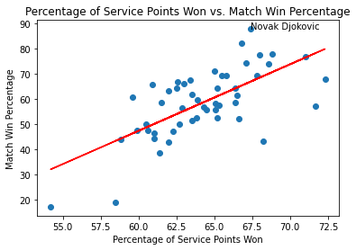

```python
winPerc = df['M W%'].to_numpy()
SPW = df['SPW'].to_numpy().reshape((-1,1))

lm = linear_model.LinearRegression()
lm.fit(SPW, winPerc)
fig3, ax3, = plt.subplots()

ax3.scatter(SPW, winPerc)
ax3.plot(SPW, lm.predict(SPW), color='red')
ax3.set(xlabel="Percentage of Service Points Won", ylabel="Match Win Percentage", title="Percentage of Service Points Won vs. Match Win Percentage")

novakDF = df[df['Player'] == "Novak Djokovic [SRB]"]
novakX = df['SPW'][0]
novakMWP = novakDF['M W%'][0]
plt.text(novakX, novakMWP, "Novak Djokovic")

scipy_value = r2_score(winPerc, lm.predict(SPW))
scipy_value
```

```
0.25711741003324806
```

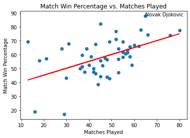

```python
matches = df['M'].to_numpy().reshape((-1,1))

lm = linear_model.LinearRegression()
lm.fit(matches, winPerc)
fig3, ax3, = plt.subplots()

ax3.scatter(matches, winPerc)
ax3.plot(matches, lm.predict(matches), color='red')
ax3.set(xlabel="Matches Played", ylabel="Match Win Percentage", title="Match Win Percentage vs. Matches Played")

novakX = df['M'][0]
plt.text(novakX, novakMWP, "Novak Djokovic")

scipy_value = r2_score(winPerc, lm.predict(matches))
scipy_value
```

```
0.4915567427762051
```

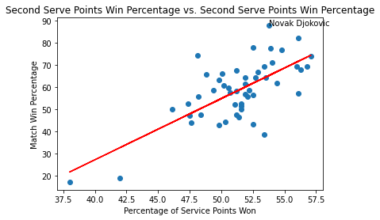

```python
secondSPW = df['2nd%'].to_numpy().reshape((-1,1))

lm = linear_model.LinearRegression()
lm.fit(secondSPW, winPerc)
fig3, ax3, = plt.subplots()

ax3.scatter(secondSPW, winPerc)
ax3.plot(secondSPW, lm.predict(secondSPW), color='red')
ax3.set(xlabel="Percentage of Service Points Won", ylabel="Match Win Percentage", title="Second Serve Points Win Percentage vs. Second Serve Points Win Percentage")

novakX = df['2nd%'][0]
plt.text(novakX, novakMWP, "Novak Djokovic")

scipy_value = r2_score(winPerc, lm.predict(secondSPW))
scipy_value
```

```
0.46570972014756606
```

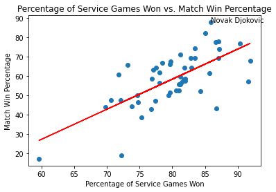

```python
holds = df['Hld%'].to_numpy().reshape((-1,1))

lm = linear_model.LinearRegression()
lm.fit(holds, winPerc)
fig3, ax3, = plt.subplots()

ax3.scatter(holds, winPerc)
ax3.plot(holds, lm.predict(holds), color='red')
ax3.set(xlabel="Percentage of Service Games Won", ylabel="Match Win Percentage", title="Percentage of Service Games Won vs. Match Win Percentage")

novakX = df['Hld%'][0]
plt.text(novakX, novakMWP, "Novak Djokovic")

scipy_value = r2_score(winPerc, lm.predict(holds))
scipy_value
```

```
0.4484028191087308
```

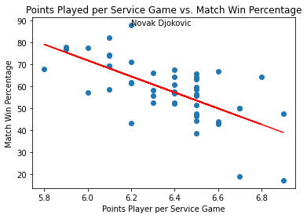

```python
ptsSG = df['Pts/SG'].to_numpy().reshape((-1,1))

lm = linear_model.LinearRegression()
lm.fit(ptsSG, winPerc)
fig3, ax3, = plt.subplots()

ax3.scatter(ptsSG, winPerc)
ax3.plot(ptsSG, lm.predict(ptsSG), color='red')
ax3.set(xlabel="Points Player per Service Game", ylabel="Match Win Percentage", title="Points Played per Service Game vs. Match Win Percentage")

novakX = df['Pts/SG'][0]
plt.text(novakX, novakMWP, "Novak Djokovic")

scipy_value = r2_score(winPerc, lm.predict(ptsSG))
scipy_value
```

```
0.49338251968395486
```

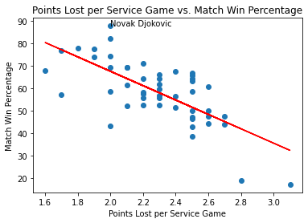

```python
ptsLSG = df['PtsL/SG'].to_numpy().reshape((-1,1))

lm = linear_model.LinearRegression()
lm.fit(ptsLSG, winPerc)
fig3, ax3, = plt.subplots()

ax3.scatter(ptsLSG, winPerc)
ax3.plot(ptsLSG, lm.predict(ptsLSG), color='red')
ax3.set(xlabel="Points Lost per Service Game", ylabel="Match Win Percentage", title="Points Lost per Service Game vs. Match Win Percentage")

novakX = df['PtsL/SG'][0]
plt.text(novakX, novakMWP, "Novak Djokovic")

scipy_value = r2_score(winPerc, lm.predict(ptsLSG))
scipy_value
```

```
0.4038015448754756
```

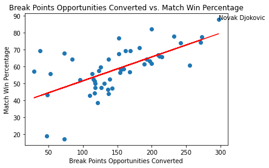

```python
BPConv = df['BPConv'].to_numpy().reshape((-1,1))

lm = linear_model.LinearRegression()
lm.fit(BPConv, winPerc)
fig3, ax3, = plt.subplots()

ax3.scatter(BPConv, winPerc)
ax3.plot(BPConv, lm.predict(BPConv), color='red')
ax3.set(xlabel="Break Points Opportunities Converted", ylabel="Match Win Percentage", title="Break Points Opportunities Converted vs. Match Win Percentage")

novakX = df['BPConv'][0]
plt.text(novakX, novakMWP, "Novak Djokovic")

scipy_value = r2_score(winPerc, lm.predict(BPConv))
scipy_value
```

```
0.3673102570095984
```

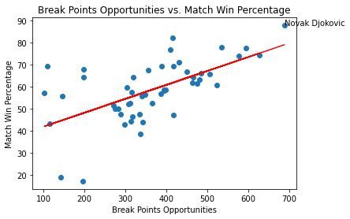

```python
BPChnc = df['BPChnc'].to_numpy().reshape((-1,1))

lm = linear_model.LinearRegression()
lm.fit(BPChnc, winPerc)
fig3, ax3, = plt.subplots()

ax3.scatter(BPChnc, winPerc)
ax3.plot(BPChnc, lm.predict(BPChnc), color='red')
ax3.set(xlabel="Break Points Opportunities", ylabel="Match Win Percentage", title="Break Points Opportunities vs. Match Win Percentage")

novakX = df['BPChnc'][0]
plt.text(novakX, novakMWP, "Novak Djokovic")

scipy_value = r2_score(winPerc, lm.predict(BPChnc))
scipy_value
```

```
0.24557071381550466
```

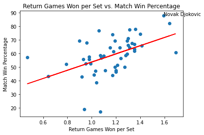

```python
BksServ = df['Bks/S'].to_numpy().reshape((-1,1))

lm = linear_model.LinearRegression()
lm.fit(BksServ, winPerc)
fig3, ax3, = plt.subplots()

ax3.scatter(BksServ, winPerc)
ax3.plot(BksServ, lm.predict(BksServ), color='red')
ax3.set(xlabel="Return Games Won per Set", ylabel="Match Win Percentage", title="Return Games Won per Set vs. Match Win Percentage")

novakX = df['Bks/S'][0]
plt.text(novakX, novakMWP, "Novak Djokovic")

scipy_value = r2_score(winPerc, lm.predict(BksServ))
scipy_value
```

```
0.3135639110093229
```

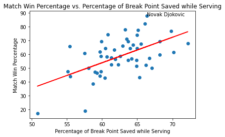

```python
BPSvdP = df['BPSvd%'].to_numpy().reshape((-1,1))

lm = linear_model.LinearRegression()
lm.fit(BPSvdP, winPerc)
fig3, ax3, = plt.subplots()

ax3.scatter(BPSvdP, winPerc)
ax3.plot(BPSvdP, lm.predict(BPSvdP), color='red')
ax3.set(xlabel="Percentage of Break Point Saved while Serving", ylabel="Match Win Percentage", title="Match Win Percentage vs. Percentage of Break Point Saved while Serving")

novakX = df['BPSvd%'][0]
plt.text(novakX, novakMWP, "Novak Djokovic")

scipy_value = r2_score(winPerc, lm.predict(BPSvdP))
scipy_value
```

```
0.399102841070606
```

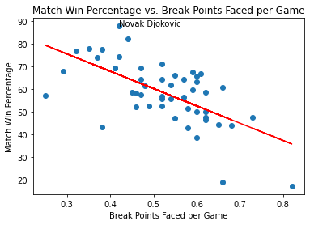

```python
BPvsG = df['BPvs/G'].to_numpy().reshape((-1,1))

lm = linear_model.LinearRegression()
lm.fit(BPvsG, winPerc)
fig3, ax3, = plt.subplots()

ax3.scatter(BPvsG, winPerc)
ax3.plot(BPvsG, lm.predict(BPvsG), color='red')
ax3.set(xlabel="Break Points Faced per Game", ylabel="Match Win Percentage", title="Match Win Percentage vs. Break Points Faced per Game")

novakX = df['BPvs/G'][0]
plt.text(novakX, novakMWP, "Novak Djokovic")

scipy_value = r2_score(winPerc, lm.predict(BPvsG))
scipy_value
```

```
0.5037449182911656
```

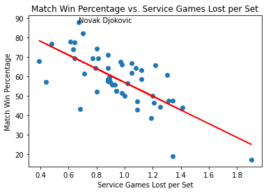

```python
BknpS = df['Bkn/S'].to_numpy().reshape((-1,1))

lm = linear_model.LinearRegression()
lm.fit(BknpS, winPerc)
fig3, ax3, = plt.subplots()

ax3.scatter(BknpS, winPerc)
ax3.plot(BknpS, lm.predict(BknpS), color='red')
ax3.set(xlabel="Service Games Lost per Set", ylabel="Match Win Percentage", title="Match Win Percentage vs. Service Games Lost per Set")

novakX = df['Bkn/S'][0]
plt.text(novakX, novakMWP, "Novak Djokovic")

scipy_value = r2_score(winPerc, lm.predict(BknpS))
scipy_value
```

It is evident from the scatter plots with linear regressions that Novak Djokovic excels in a number of various aspects in his game. For every graph, the point representing Djokovic is sitting well above the linear regression line. To further our analysis of this data we are going to step away from examining Djokovic and look at these variables as a grouping. To this point we have created single linear regressions in regards to the correlations between match win percentage and a variety of other variables it is moderate to highly correlated with. These other variables have been treated as independent variables, and we are going to try to see if they are truly independent, which would allow for us to use multiple linear regression to represent match win percentage and the variable it depends on. We will plot another correlation matrix through a seaborn heatmap, this time using the reduced column variables. This will have the same information as the correlation matrix in section 3, but will be more readable and easier to compare all variables in the matrix instead of focusing on a single column. In order to accomplish this, a subset of the tennis dataframe will be created.

```python
dfSubSet = df[['M W%', 'M', 'SPW', '2nd%', 'Hld%', 'Pts/SG', 'PtsL/SG', 'BPConv', 'BPChnc', 'Bks/S', 'BPSvd%', 'BPvs/G', 'Bkn/S']]
dfSubSet
```

|  | M W% | M | SPW | 2nd% | Hld% | Pts/SG | PtsL/SG | BPConv | BPChnc | Bks/S | BPSvd% | BPvs/G | Bkn/S |
| --- | --- | --- | --- | --- | --- | --- | --- | --- | --- | --- | --- | --- | --- |
| 0 | 87.7 | 65 | 67.4 | 53.8 | 85.9 | 6.2 | 2.0 | 297 | 688 | 1.59 | 66.4 | 0.42 | 0.67 |
| 1 | 77.8 | 63 | 68.8 | 52.5 | 87.1 | 5.9 | 1.8 | 232 | 535 | 1.36 | 63.3 | 0.35 | 0.61 |
| 2 | 82.2 | 45 | 66.8 | 56.1 | 85.1 | 6.1 | 2.0 | 200 | 416 | 1.64 | 66.1 | 0.44 | 0.70 |
| 3 | 73.7 | 76 | 68.6 | 57.1 | 87.2 | 6.1 | 1.9 | 242 | 578 | 1.17 | 65.0 | 0.37 | 0.63 |
| 4 | 74.2 | 66 | 67.1 | 48.1 | 83.5 | 6.1 | 2.0 | 271 | 628 | 1.40 | 60.8 | 0.42 | 0.80 |
| 5 | 64.1 | 39 | 65.2 | 51.9 | 81.9 | 6.4 | 2.2 | 137 | 319 | 1.23 | 65.0 | 0.52 | 0.88 |
| 6 | 77.5 | 80 | 68.0 | 53.9 | 86.6 | 6.0 | 1.9 | 273 | 594 | 1.31 | 65.1 | 0.38 | 0.64 |
| 7 | 76.9 | 52 | 71.0 | 54.8 | 90.4 | 5.9 | 1.7 | 152 | 410 | 1.06 | 69.8 | 0.32 | 0.48 |
| 8 | 69.2 | 13 | 67.8 | 56.8 | 87.1 | 6.1 | 2.0 | 38 | 110 | 0.90 | 68.2 | 0.41 | 0.64 |
| 9 | 61.4 | 57 | 66.5 | 51.9 | 85.7 | 6.2 | 2.1 | 189 | 475 | 1.18 | 70.2 | 0.48 | 0.71 |
| 10 | 71.2 | 52 | 65.0 | 54.0 | 81.2 | 6.2 | 2.2 | 182 | 431 | 1.30 | 63.5 | 0.52 | 0.88 |
| 11 | 57.4 | 47 | 65.3 | 50.7 | 82.0 | 6.4 | 2.2 | 123 | 316 | 0.98 | 61.3 | 0.47 | 0.88 |
| 12 | 60.7 | 56 | 59.6 | 50.2 | 71.8 | 6.4 | 2.6 | 255 | 523 | 1.69 | 57.5 | 0.66 | 1.30 |
| 13 | 69.1 | 55 | 65.8 | 56.0 | 83.5 | 6.1 | 2.1 | 169 | 417 | 1.19 | 59.9 | 0.41 | 0.77 |
| 14 | 58.6 | 58 | 66.4 | 52.2 | 82.0 | 6.1 | 2.0 | 159 | 398 | 1.07 | 59.8 | 0.45 | 0.88 |
| 15 | 61.8 | 55 | 63.5 | 54.4 | 78.1 | 6.2 | 2.3 | 200 | 463 | 1.35 | 59.7 | 0.54 | 1.05 |
| 16 | 56.3 | 48 | 62.9 | 52.5 | 78.1 | 6.5 | 2.4 | 154 | 349 | 1.24 | 61.9 | 0.57 | 1.02 |
| 17 | 18.8 | 16 | 58.5 | 42.0 | 72.2 | 6.7 | 2.8 | 47 | 142 | 0.94 | 57.6 | 0.66 | 1.34 |
| 18 | 58.5 | 41 | 61.5 | 49.4 | 76.9 | 6.5 | 2.5 | 155 | 395 | 1.28 | 62.6 | 0.62 | 1.12 |
| 19 | 50.0 | 36 | 60.5 | 46.1 | 74.7 | 6.7 | 2.6 | 118 | 274 | 1.27 | 58.1 | 0.60 | 1.20 |
| 20 | 59.5 | 37 | 63.9 | 50.6 | 81.2 | 6.5 | 2.3 | 126 | 303 | 1.29 | 68.2 | 0.59 | 0.89 |
| 21 | 67.7 | 31 | 72.3 | 56.3 | 91.9 | 5.8 | 1.6 | 73 | 198 | 0.96 | 72.2 | 0.29 | 0.39 |
| 22 | 66.7 | 60 | 62.6 | 52.9 | 78.5 | 6.6 | 2.5 | 209 | 450 | 1.35 | 64.4 | 0.61 | 1.05 |
| 23 | 69.4 | 49 | 65.5 | 53.4 | 82.8 | 6.1 | 2.1 | 162 | 389 | 1.29 | 63.7 | 0.47 | 0.81 |
| 24 | 56.6 | 53 | 64.3 | 51.9 | 81.4 | 6.4 | 2.3 | 168 | 387 | 1.08 | 64.2 | 0.52 | 0.90 |
| 25 | 58.2 | 55 | 65.1 | 51.2 | 81.8 | 6.3 | 2.2 | 156 | 395 | 1.10 | 60.7 | 0.46 | 0.89 |
| 26 | 50.0 | 42 | 62.7 | 51.6 | 79.4 | 6.7 | 2.5 | 131 | 282 | 1.19 | 67.1 | 0.62 | 1.00 |
| 27 | 52.2 | 46 | 66.6 | 51.1 | 84.3 | 6.4 | 2.1 | 96 | 307 | 0.79 | 66.2 | 0.46 | 0.80 |
| 28 | 55.6 | 18 | 64.5 | 52.1 | 81.2 | 6.5 | 2.3 | 53 | 145 | 0.98 | 63.7 | 0.52 | 0.91 |
| 29 | 66.1 | 62 | 63.0 | 50.1 | 79.6 | 6.3 | 2.3 | 211 | 484 | 1.30 | 62.9 | 0.55 | 0.98 |
| 30 | 47.4 | 38 | 59.9 | 48.4 | 72.1 | 6.5 | 2.6 | 118 | 289 | 1.20 | 55.1 | 0.62 | 1.31 |
| 31 | 43.3 | 30 | 68.2 | 52.5 | 86.7 | 6.2 | 2.0 | 48 | 115 | 0.64 | 65.3 | 0.38 | 0.68 |
| 32 | 64.3 | 28 | 66.4 | 53.5 | 82.9 | 6.8 | 2.3 | 84 | 198 | 1.15 | 64.0 | 0.47 | 0.79 |
| 33 | 51.4 | 37 | 63.5 | 51.6 | 79.6 | 6.5 | 2.4 | 117 | 271 | 1.21 | 64.9 | 0.58 | 0.98 |
| 34 | 65.5 | 58 | 60.9 | 48.8 | 73.2 | 6.5 | 2.5 | 215 | 506 | 1.41 | 55.4 | 0.60 | 1.22 |
| 35 | 55.6 | 45 | 65.1 | 48.2 | 81.0 | 6.3 | 2.2 | 113 | 341 | 0.93 | 64.9 | 0.54 | 0.93 |
| 36 | 52.5 | 40 | 65.2 | 51.6 | 81.0 | 6.3 | 2.2 | 115 | 312 | 0.99 | 61.3 | 0.49 | 0.94 |
| 37 | 64.2 | 53 | 62.5 | 52.7 | 77.5 | 6.5 | 2.5 | 193 | 466 | 1.31 | 60.5 | 0.57 | 1.08 |
| 38 | 57.1 | 21 | 71.7 | 56.1 | 91.6 | 6.0 | 1.7 | 29 | 102 | 0.47 | 66.7 | 0.25 | 0.44 |
| 39 | 52.5 | 59 | 63.8 | 47.4 | 80.6 | 6.4 | 2.3 | 139 | 365 | 0.95 | 62.3 | 0.52 | 0.94 |
| 40 | 42.9 | 49 | 62.0 | 49.8 | 76.8 | 6.6 | 2.5 | 110 | 298 | 0.92 | 60.4 | 0.58 | 1.09 |
| 41 | 43.8 | 48 | 58.8 | 47.6 | 69.8 | 6.6 | 2.7 | 137 | 342 | 1.17 | 55.5 | 0.68 | 1.41 |
| 42 | 46.5 | 43 | 61.0 | 51.4 | 74.8 | 6.5 | 2.5 | 136 | 317 | 1.20 | 59.3 | 0.62 | 1.21 |
| 43 | 44.4 | 45 | 61.0 | 50.3 | 73.8 | 6.5 | 2.6 | 117 | 313 | 1.02 | 59.7 | 0.65 | 1.25 |
| 44 | 38.6 | 44 | 61.4 | 53.4 | 75.3 | 6.5 | 2.5 | 121 | 336 | 1.04 | 58.7 | 0.60 | 1.19 |
| 45 | 63.2 | 57 | 62.0 | 49.8 | 77.1 | 6.5 | 2.5 | 197 | 481 | 1.35 | 61.7 | 0.60 | 1.12 |
| 46 | 67.4 | 43 | 63.4 | 51.2 | 79.7 | 6.4 | 2.4 | 152 | 355 | 1.33 | 65.5 | 0.59 | 0.97 |
| 47 | 47.2 | 53 | 62.3 | 47.5 | 77.4 | 6.5 | 2.5 | 142 | 418 | 1.03 | 59.0 | 0.55 | 1.09 |
| 48 | 17.2 | 29 | 54.2 | 38.0 | 59.6 | 6.9 | 3.1 | 73 | 196 | 1.07 | 50.8 | 0.82 | 1.90 |
| 49 | 47.6 | 42 | 60.6 | 51.2 | 70.6 | 6.9 | 2.7 | 127 | 334 | 1.11 | 59.8 | 0.73 | 1.34 |

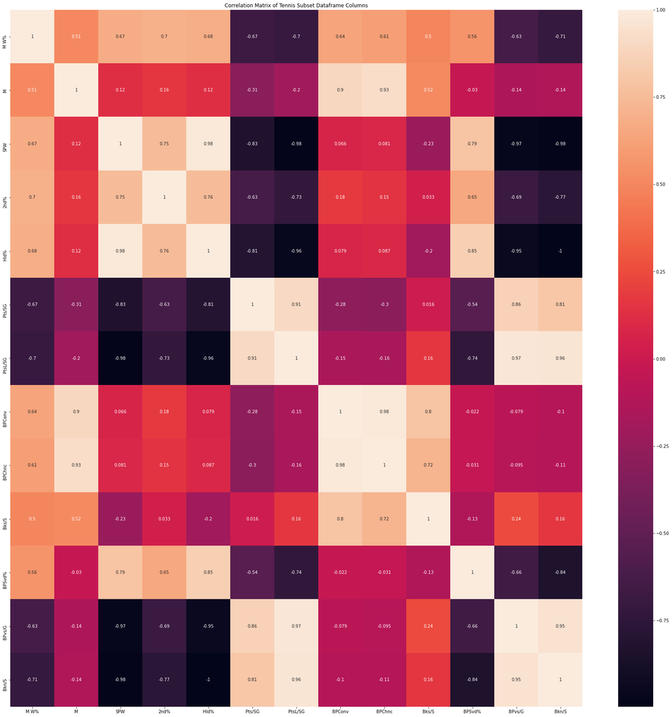

```python
plt.subplots(figsize = (30,30))
g = sns.heatmap(dfSubSet.corr(), annot = True)

g.set_title("Correlation Matrix of Tennis Subset Dataframe Columns")
```